# Predicting the Quality of Weight Lifting

## Executive Summary

One thing that people regularly do is quantify how much of a particular activity they do, but they rarely quantify how well they do it. This analysis uses data from accelerometers on the belt, forearm, arm, and dumbell of 6 participants to classify the quality of barbell lifts. More information is available from the website here: http://groupware.les.inf.puc-rio.br/har (see the section on the Weight Lifting Exercise Dataset).

```r
# - load packages
library(knitr)          # - report writing
library(ggplot2)        # - plotting
library(gridExtra)      # - panel plots
library(dplyr)          # - data manipulation
library(readr)          # - fast csv reads
library(RCurl)          # - network interface
library(lubridate)      # - date functions
library(Metrics)        # - supervised learning evaluation metrics
library(Hmisc)          # - miscellaneous data analysis function
library(MASS)           # - applied stats methods
library(class)          # - functions for classification
library(caret)          # - model training functions
library(pryr)           # - check memory
library(rpart)          # - regression trees
library(rattle)         # - regression tree plots
library(gbm)            # - boosting with trees
library(corrgram)       # - correlogram
library(stargazer)      # - format tables
```

## User Defined Functions

**Load Data**: define data schema and drop columns that have more than 90% missing values. **Write Predictions**: for each of the 20 unclassified observations, write a text file with its predicted class.

```r
# - load data and clean
load_data <- function(path)
{
    # - required libraries
    require(RCurl)          # - network interface
    require(dplyr)          # - data manipulation
    require(lubridate)      # - date functions

    # - debugging
    #path <- url_test

    # - download the url
    url_path <- RCurl::getURL(path)

    # - load data
    df_data <- read.csv(textConnection(url_path), stringsAsFactors=FALSE,
        na.strings = c("NA","","#DIV/0!"))

    # - update
    df_data <- df_data %>%
        dplyr::rename(row_num = X) %>%
        dplyr::mutate(
            cvtd_timestamp = lubridate::fast_strptime(cvtd_timestamp, "%m/%d/%Y %H:%M"),
            new_window = as.factor(new_window),
            user_name = as.factor(user_name)
        ) %>%
        dplyr::select(-row_num)

    if ( grepl("training", path) )
    {
        df_data$classe = as.factor(df_data$classe)
    }

    # - many columns that are 90%+ na values, lets drop those
    # - find variables with more than 90% na
    #df_na <- data.frame("na_pct" = sapply(df_data, function(x) sum(is.na(x))/length(x)))
    #df_na$var <- rownames(df_na)
    #df_na <- df_na %>% dplyr::select(var,na_pct) %>% dplyr::arrange(desc(na_pct))

    # - remove high pct na columns
    #   no more NA columns in train/test data after this
    df_data <- df_data[, colSums(is.na(df_data))/nrow(df_data) < .9]

    # - confirm no NAs
    #sapply(df_data, function(x) sum(is.na(x))/length(x))

    # - return
    invisible(df_data)
}

# - generate submission files
pml_write_files <- function(x)
{
    n = length(x)
    for(i in 1:n)
    {
        filename = file.path(paste0("problem_id_",i,".txt"))
        write.table(x[i],file=filename,quote=FALSE,row.names=FALSE,col.names=FALSE)
    }
}
```

## Load Data and Split into Train/Test Sets

After loading the data we split the data into 80% training (for model fitting) and set aside 20% for out-of-sample testing.

```r
# - Notes on Data Set:
#   http://groupware.les.inf.puc-rio.br/public/papers/2013.Velloso.QAR-WLE.pdf
#   > sensors: belt, glove, dumbbell, arm-band
#   > measurements: three-axes acceleration, gyroscope, magnetometer
#       > gyroscope: measures orientation
#       > magnetometer: estimate body inclination while being insensitive to acceleration
#   > Class: A is correct, other 4 classes correspond to common mistakes
#       > good - A
#       > bad - B: elbows to front, C: up halfway, D: down half, E: throw hips
#   > Euler angles (roll, pitch, and yaw) - "aircraft principal axes"
#       > An aircraft in flight is free to rotate in three dimensions:
#       > pitch - nose up or down about an axis running from wing to wing
#       > yaw - nose left or right about an axis running up and down
#       > roll - rotation about an axis running from nose to tail

# - data urls
url_train <- "https://d396qusza40orc.cloudfront.net/predmachlearn/pml-training.csv"
url_test <- "https://d396qusza40orc.cloudfront.net/predmachlearn/pml-testing.csv"

# - model fit paths (to avoid rerunning)
path_fit_gbm <- "fit_gbm.rds"
path_fit_rf <- "fit_rf.rds"
path_fit_rpart <- "fit_rpart.rds"

# - load data sets
#   the test file is only 20 observattions and is used for part 2 of assignment
df_data <- load_data(url_train)
df_evaluation <- load_data(url_test)

# - data dimensions
# dim(df_data)
# dim(df_evaluation)
# - confirm columns are the same (other than classification)
# colnames(df_data)[!(colnames(df_data) %in% colnames(df_evaluation))]

# - split into proper training and test
train_index <- caret::createDataPartition(y=df_data$classe, p=0.8, list=FALSE, times=1)
df_train <- df_data[train_index,]
df_test <-  df_data[-train_index,]

# - check proportions in test and train
tbl_train <- round(prop.table(table(df_train$classe)),2)*100
tbl_test <- round(prop.table(table(df_test$classe)),2)*100
tbl_train
```

```
##
##  A  B  C  D  E
## 28 19 17 16 18
```

```r
tbl_test
```

```
##
##  A  B  C  D  E
## 28 19 17 16 18
```

```r
tbl_train - tbl_test
```

```
##
## A B C D E
## 0 0 0 0 0
```

```r
# - removing fields that wont be used for model fitting
df_train_num <- df_train %>% dplyr::select(-user_name, -raw_timestamp_part_1, -raw_timestamp_part_2, -cvtd_timestamp, -new_window)

# - limit to only regressors
df_train_num_x <- df_train_num %>% dplyr::select(-classe)
```

## Data Visualization

Given the data has a high degree of dimensions, we first explore the correlation of the data set and then then investigate the classification by accelerometer location. The correlation is generally larger across sensors for a given location but less so across sensor locations (see table below). We fit a single regression tree to the data which turns out to be an inaccurate predictor. Based on PCA plots the the belt sensor tends to predict class E (throwing hips in front) while the other sensors are not-interpretable based on the first two PCs (see arm plot below).

```r
# - correlation: regressors > 80%
corm <- cor(df_train_num_x); diag(corm) <- 0
corm_filter <- which(abs(corm) > 0.8, arr.ind=TRUE)
top_cor <- data.frame(
    row=corm_filter[,"row"], row_name=rownames(corm_filter),
    col=corm_filter[,"col"], col_name=colnames(corm)[as.vector(corm_filter[,"col"])])
top_cor$key = apply(top_cor[,c("row","col")],1,
    function(m) ifelse(m['row']<m['col'], paste(m['row'],m['col'],sep="_"),
        paste(m['col'],m['row'],sep="_")))
top_cor <- dplyr::distinct(top_cor, key)
top_cor$cor = apply(top_cor[,c("row","col")],1,
    function(m) round(corm[m['row'],m['col']]*100,2))
dplyr::arrange(dplyr::select(top_cor,-key,-row,-col),desc(abs(cor)))
```

```
##            row_name         col_name    cor
## 1      accel_belt_z        roll_belt -99.20
## 2  total_accel_belt        roll_belt  98.09
## 3      accel_belt_z total_accel_belt -97.51
## 4      accel_belt_x       pitch_belt -96.60
## 5      accel_belt_z     accel_belt_y -93.35
## 6      accel_belt_y total_accel_belt  92.68
## 7      accel_belt_y        roll_belt  92.46
## 8       gyros_arm_y      gyros_arm_x -91.80
## 9     magnet_belt_x     accel_belt_x  89.90
## 10    magnet_belt_x       pitch_belt -89.13
## 11 accel_dumbbell_z     yaw_dumbbell  84.95
## 12         yaw_belt        roll_belt  81.50
## 13     magnet_arm_z     magnet_arm_y  81.36
## 14     magnet_arm_x      accel_arm_x  81.26
## 15 accel_dumbbell_x   pitch_dumbbell  80.87
```

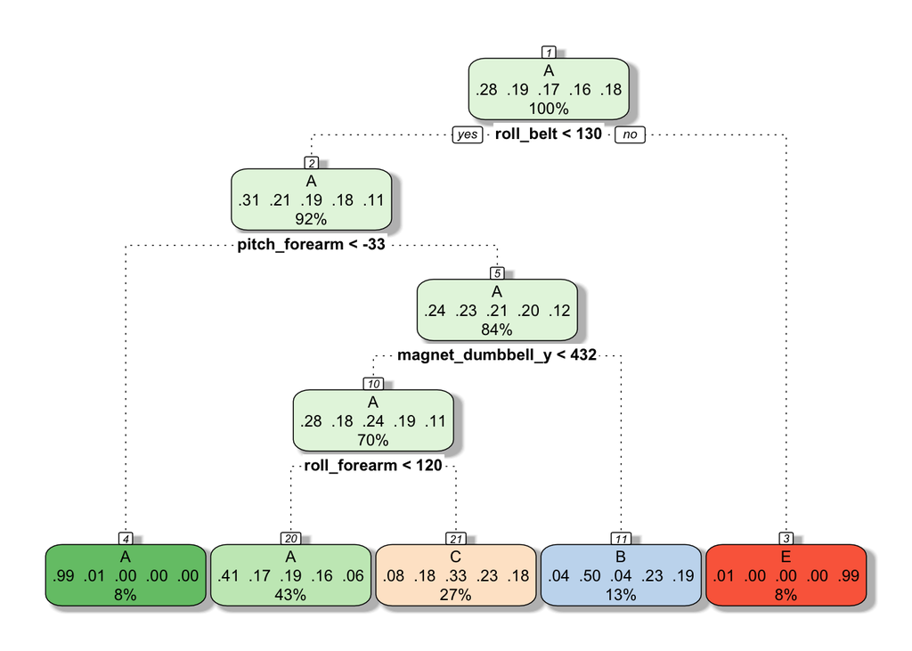

```r
# - fit: single tree classification to help visualize
#   commenting out fitting after running, long run time
# fit_rpart <- caret::train(classe~., method="rpart", data=df_train_num)
# saveRDS(fit_rpart, path_fit_rpart)
fit_rpart <- readRDS(path_fit_rpart)
# - plot: single tree
rattle::fancyRpartPlot(fit_rpart$finalModel, sub="")
```

```r
# - accuracy: single tree - bad, doesnt predict D (most likely too related to C)
cm_rpart_train <- caret::confusionMatrix(df_train$classe, predict(fit_rpart, newdata=df_train_num))
cm_rpart_train$overall; cm_rpart_train$table
```

```
##       Accuracy          Kappa  AccuracyLower  AccuracyUpper   AccuracyNull
##      0.4972928      0.3437328      0.4894408      0.5051458      0.5111791
## AccuracyPValue  McnemarPValue
##      0.9997568            NaN
```

```
##           Reference
## Prediction    A    B    C    D    E
##          A 4037   89  326    0   12
##          B 1209 1057  772    0    0
##          C 1261   97 1380    0    0
##          D 1112  472  989    0    0
##          E  406  401  746    0 1333
```

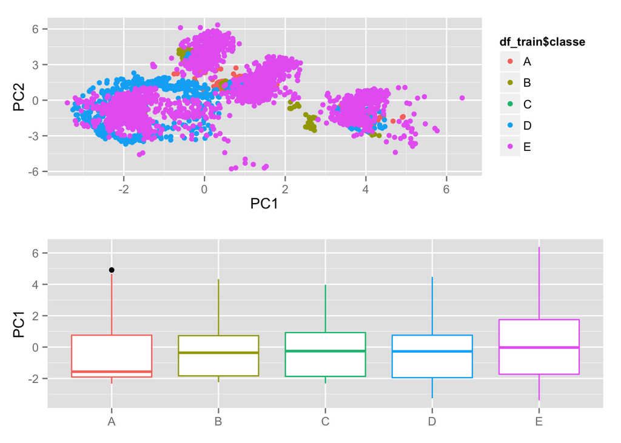

```r
# - grab column names by sensor location
# paste(grep("_belt",colnames(df_train), value=T), collapse = ",")
# paste(grep("_arm",colnames(df_train), value=T), collapse = ",")
# paste(grep("_dumbbell",colnames(df_train), value=T), collapse = ",")
# paste(grep("_forearm",colnames(df_train), value=T), collapse = ",")


# - belt
df_train_belt <- dplyr::select(df_train, roll_belt,pitch_belt,yaw_belt,gyros_belt_x,gyros_belt_y,gyros_belt_z,accel_belt_x,accel_belt_y,accel_belt_z,magnet_belt_x,magnet_belt_y,magnet_belt_z)
pca_belt <- caret::preProcess(df_train_belt, method=c("center", "scale", "pca"), pcaComp=2)
pred_pca_belt <- predict(pca_belt, df_train_belt)
g1_belt <- qplot(x=PC1, y=PC2, data=pred_pca_belt, colour=df_train$classe)
g2_belt <- ggplot(data=pred_pca_belt, aes(x=df_train$classe, y=PC1, colour=df_train$classe)) + geom_boxplot() + theme(axis.title.x = element_blank(), legend.position='none') + labs(x="")
gridExtra::grid.arrange(g1_belt,g2_belt, nrow=2)
```

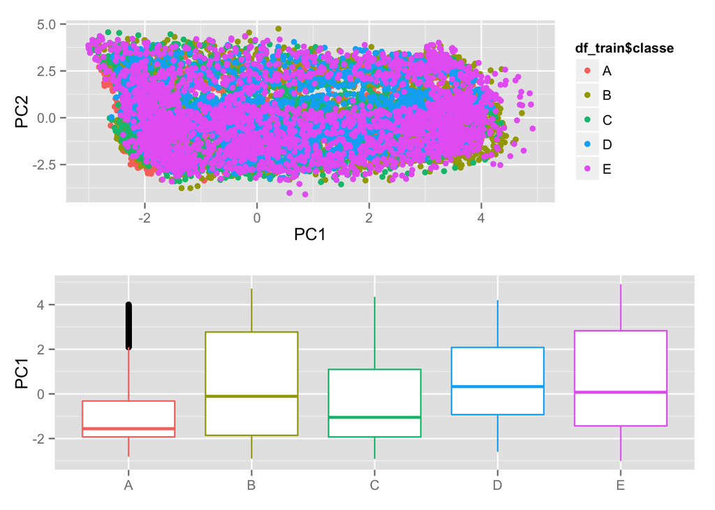

```r
# - arm
df_train_arm <- dplyr::select(df_train, roll_arm,pitch_arm,yaw_arm,total_accel_arm,gyros_arm_x,gyros_arm_y,gyros_arm_z,accel_arm_x,accel_arm_y,accel_arm_z,magnet_arm_x,magnet_arm_y,magnet_arm_z)
pca_arm <- caret::preProcess(df_train_arm, method=c("center", "scale", "pca"), pcaComp=2)
pred_pca_arm <- predict(pca_arm, df_train_arm)
g1_arm <- qplot(x=PC1, y=PC2, data=pred_pca_arm, colour=df_train$classe)
g2_arm <- ggplot(data=pred_pca_arm, aes(x=df_train$classe, y=PC1, colour=df_train$classe)) + geom_boxplot() + theme(axis.title.x = element_blank(), legend.position='none') + labs(x="")
gridExtra::grid.arrange(g1_arm,g2_arm, nrow=2)
```